# Life-history evolution in ants: the case of Cardiocondyla | Proceedings of the Royal Society B: Biological Sciences

[figure not shown]

Review article

# Life-history evolution in ants: the case of *Cardiocondyla*

Jürgen Heinze

Published:15 March 2017https://doi.org/10.1098/rspb.2016.1406

## Abstract

Ants are important components of most terrestrial habitats, and a better knowledge of the diversity of their life histories is essential to understand many aspects of ecosystem functioning. The myrmicine genus *Cardiocondyla* shows a wide range of colony structures, reproductive behaviours, queen and male lifespans, and habitat use. Reconstructing the evolutionary pathways of individual and social phenotypic traits suggests that the ancestral life history of *Cardiocondyla* was characterized by the presence of multiple, short-lived queens in small-sized colonies and a male polyphenism with winged dispersers and wingless fighters, which engage in lethal combat over female sexuals within their natal nests. Single queening, queen polyphenism, the loss of winged males and tolerance among wingless males appear to be derived traits that evolved with changes in nesting habits, colony size and the spread from tropical to seasonal environments. The aim of this review is to bring together the information on life-history evolution in *Cardiocondyla* and to highlight the suitability of this genus for functional genomic studies of adaptation, phenotypic plasticity, senescence, invasiveness and other key life-history traits of ants.

### 1. Introduction

Comparisons among species that live in different environments have been valuable to uncover how ecological factors have shaped an organism's life history (e.g. [1–3]). In social insects, the ant genus *Cardiocondyla*, with probably 100 species or more, is particularly suitable for studies on life-history evolution, because its species vary in habitat preferences, nesting sites, queen number, queen mating frequency, male mating tactics and longevity. Furthermore, through the ease with which *Cardiocondyla* colonies can be maintained in large numbers in the laboratory and with which sexuals mate under controlled conditions, the genus lends itself for experimental manipulations of individual and colony phenotype. The now available genome sequence of *Cardiocondyla obscurior* [4] further allows tackling evolutionary questions down to the level of individual genes. The aim of my review is not to provide a full comparison of *Cardiocondyla* with other social insects but to bring together data about this genus, which describe the diversity of its life cycles, and to highlight its suitability for future functional genomic studies of life-history traits.

### 2. Who is *Cardiocondyla*?

*Cardiocondyla* are tiny myrmicine ants with 1.5–3 mm body size in the worker caste. Queens and workers are characterized by their postpetiole in dorsal view being much broader than the petiole and often roughly heart-shaped (hence the genus name). Typical colonies consist of a few dozen or hundred workers and one or several queens. They live in small chambers in soil, rock crevices or plant material, such as folded leaves, galls or dead twigs. Seifert [5] recognized 48 species in samples from Europe, Africa and continental Asia, but estimated that the total number of species may well exceed 100. Unfortunately, many species can be distinguished only by meticulous morphometry of large nest samples and subsequent multivariate statistics or by genetic barcoding [5–7]. Consequently, several species are often confused (e.g. *Cardiocondyla venustula* and *Cardiocondyla shuckardi*; *Cardiocondyla wroughtonii* and *C. obscurior; Cardiocondyla**kagutsuchi*, *Cardiocondyla nuda*, *Cardiocondyla mauritanica* and *C. venustula*), and several ‘species’ have only recently been recognized to consist of multiple distinct genetic lineages [6,8,9]. The internal phylogeny of the genus has largely been clarified by sequencing mitochondrial and nuclear genes in 27 species [10] covering most of the species groups recognized by Seifert based on morphology ([5], B. Seifert 2007, personal communication). However, the exact position of *Cardiocondyla* within the ant subfamily Myrmicinae is still dubious. In earlier studies, *Cardiocondyla* clustered with *Temnothorax* and *Leptothorax* [11] or *Solenopsis* [12], but because of a long branch its position was reported to be unstable in the most recent study [13].

### 3. From Wallacea to everywhere

The geographical occurrence of the earliest-branching species in the phylogeny of *Cardiocondyla* [10] suggests an origin in the rainforests of the Indomalayan and/or Australasian ecozone, where representatives of many species groups co-occur (see the electronic supplementary material, figure S1). This is further supported by the restriction of species previously considered as belonging to a separate (sub-) genus *Prosopidris* to the Philippines and Papua [14,15]. One of the two main branches in the phylogeny consists exclusively of species native to Southeast Asian ecozones, while species from the second branch have spread to other Old World habitats, such as semi-arid steppes in Central Asia, Africa and around the Mediterranean. In such xeric environments, nests are typically found in the soil close to humidity, i.e. near irrigated ditches, river banks, sea shores or dried-out river beds, and may reach down more than 1.5 m into the ground [5,16].

At least 10 of the 27 species treated in [10] have adapted well to anthropogenic disturbance, quickly colonize rehabilitated wasteland and flourish in plantations and sparsely vegetated ruderal areas. Their ancestral life history with multiple queens per nest, colony founding by budding and mating in the nest (see below) predisposes them to become invasive [17]. Indeed, several species, such as *Cardiocondyla minutior*, *C. mauritanica*, *Cardiocondyla emeryi* and *C. obscurior*, have been introduced worldwide by human activities and successfully colonized tropical and subtropical America, isolated islands, including Hawaii, St Helena and Easter Island (e.g. [5,18,19]), and greenhouses in temperate Central Europe [20,21]. Because *Cardiocondyla* workers forage solitarily or in tandems without trail recruitment [20,22], their presence is often overlooked, but it appears that most tropical and subtropical parks and beaches around the world harbour at least one non-native species of *Cardiocondyla*. Their impact on local fauna and flora appears to be far less dramatic than that of other invasive ants, such as the infamous Argentine ant or the crazy ants. Surveys in a Brazilian plantation suggested that *C. obscurior* competed for nest sites with another invasive species, *Monomorium floricola*, but did not reveal effects on the native ant community (own observations).

### 4. Ancestral life history of *Cardiocondyla*: multiple queens and male polyphenism

The ancestral life history of *Cardiocondyla* is characterized by colonies with a few dozen or hundred workers and multiple reproductive queens (polygyny; electronic supplementary material, figure S2) and a pronounced male polyphenism with winged disperser males and wingless fighter males, which locally compete for mating with female sexuals in their natal nests (intranidal mating; figure 1; electronic supplementary material, figure S3) [10]. While polyphenism between and within the two female castes, queens and workers, is widespread among social Hymenoptera, male polyphenism is known only from a handful of genera (e.g. [23]). In *Cardiocondyla*, wingless males look so unlike other ant males that they originally have been mistaken for queens of novel socially parasitic genera (*Emeryia* [24]; *Xenometra* [25,26]) and only later recognized as ordinary *Cardiocondyla* males [16,27–28]. Though often referred to as ergatoid, i.e. ‘workerlike’ males because of their elbowed antennae, the absence of a flight apparatus and reduced ocelli, wingless *Cardiocondyla* males are not simply workers with male genitalia. Instead, their morphology differs in many details from that of workers, e.g. in coloration, the size of eyes and mandibles, and the robustness of their bodies (e.g. [5,29]). Winged *Cardiocondyla* males—like all other studied males of social Hymenoptera—have a limited sperm supply and their testes degenerate shortly after adult emergence. By contrast, the testes of wingless males persist and produce sperm throughout their lives [30]. These morphological and physiological differences are reflected in gene expression during ontogeny: in *C. obscurior*, transcriptomes of 3rd instar larvae destined to grow into wingless males differed from those of larvae developing into queens, workers or winged males in core signalling pathways, such as Notch, EGFR, Wnt and others [31].

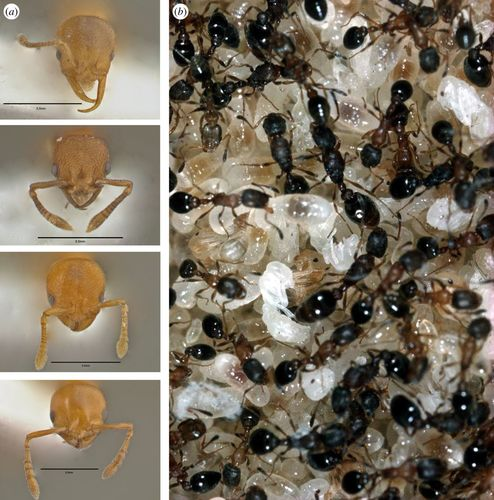

Figure 1. (*a*) Heads of wingless males of four species of the ant genus *Cardiocondyla* with different reproductive strategies (from top to bottom: *C. obscurior* – males kill freshly eclosed rivals and besmear other adult males with hindgut secretions; *C.* ‘*latifrons*’, males kill freshly eclosed rivals; *C. minutior*, males kill freshly eclosed rivals; *C. batesii*, males mutually tolerant; photos by S. Frohschammer). (*b*) Queens, workers and brood in a laboratory colony of *C. mauritanica*.

#### (a) Queen number and morphology

In social Hymenoptera, polygyny is thought to be a derived trait [40] that evolved whenever environmental conditions promoted large colony size [32] or facilitated colony propagation by fragmentation of the natal colony and the dispersal of groups of workers and queens (‘budding’ e.g. [33,38,39]). Instead, facultative polygyny and colony founding by budding appear to be ancestral traits in *Cardiocondyla*. Most colonies of tropical species are small and contain multiple fertile queens [10,41]. This probably reflects the low survival rate of solitary queens and the abundance of ephemeral nest sites in the ground, hollow branches or grass stems in the rainforests of Southeast Asia and Wallacea (e.g. [33,38,39]). Queen antagonism has not been observed in these polygynous species, even though queen number negatively affects the fitness of individual queens by lowering their egg-laying rate and shortening their lifespan [42]. The regular occurrence of queens of facultatively polygynous species that disperse on foot after mating and wing shedding in their natal nest (e.g. *C*. *emeryi, C. kagutsuchi*, *C. obscurior*, own observations) suggests that at least some queens attempt independent colony foundation. However, solitary foundings in the laboratory remained without success [43] and it is likely that in nature the majority of new colonies are founded by budding, e.g. [41]).

Two lineages—a few species of the Southeast Asian *Cardiocondyla ‘argentea’* group (preliminary name for a taxon currently being described by B. Seifert) and the large clade of Palaearctic *Cardiocondyla—*have convergently evolved single-queening (monogyny) [10,43–45]. Nevertheless, both lineages have retained intranidal mating, which results in the temporary presence of multiple potential reproductives in a single nest. In the *C.* ‘*argentea*’-group, nest-mate queens appear to establish rank orders by biting and antennal boxing. Only one or a few dominant queens lay eggs and sit on the brood pile, while others are displaced towards the periphery of the nest and lay only few eggs if at all (‘functional monogyny’, [46]). After the experimental removal of a fertile queen in colonies of *Cardiocondyla ‘latifrons’*, virgin female sexuals were observed to fight for nest inheritance, and many of them were killed during these interactions [44]. In the related *Cardiocondyla* ‘*argyrotricha*’ mated queens and female sexuals were similarly intolerant, even though their interactions were considerably less violent. All female sexuals that eclosed in a queenless colony mated with the present male, but typically only one shed its wings and started to lay eggs [45].

Colonies of monogynous Palaearctic *Cardiocondyla* may contain several hundred workers [5], and thus are typically much larger than those of tropical species. Their nests consist of many small chambers up to 1.5 m down in the soil [16] and presumably require considerable investment in construction. Colonies accept alien female sexuals and both own and adopted young queens may remain in the nest after mating until dispersal after hibernation (e.g. [47–49]). Several species, e.g. *Cardiocondyla batesii*, show a marked wing size polyphenism, suggesting the reduction of long-distance dispersal flights [5,43,50]. Not surprisingly, large numbers of dealate queens of Palaearctic *Cardiocondyla* have been observed to disperse on foot, but in contrast to similarly dispersing queens of polygynous species at least a fraction succeeded with solitary founding in the laboratory [43].

Transition from multi- to single-queening might be associated with an increased persistence of nest sites (e.g. [38]). *Cardiocondyla ‘argentea*’ lives in crevices in large boulders, which are relatively stable, but rare and patchily distributed. Solitary founding by mated, wingless queens and budding may be difficult, making nest inheritance a realistic alternative. Nevertheless, as mentioned above, many young queens of *C.* ‘*argyrotricha*’ do not shed their wings after mating [45] and, in accordance with dispersal models (e.g. [51]), may maintain their option for long-distance dispersal. Like the stable crevice nests of *C. ‘argentea’*, the nests of Palaearctic *Cardiocondyla* appear to be valuable resources for the queens, because it takes enormous efforts to dig tunnels deep enough to provide sufficient humidity from ground water during periods of drought and to protect the colony from drowning during occasional flooding. The spacing of nests suggests that areas with appropriate humidity and soil structure are limited and patchily distributed. Wing polyphenism in Palaearctic *Cardiocondyla* has been suggested to be a consequence of such a clumped distribution of nest sites [5]. However, while other species of ants have adapted to habitat patchiness and the requirement of a large workforce with the evolution of polygyny and budding [32,33], Palaearctic *Cardiocondyla* have followed the opposite evolutionary trajectory. It is surprising that despite of local resource competition sex ratios are highly female-biased [47–49] and that at least in *Cardiocondyla elegans*, workers regularly carry their female sexual sisters into the nests of unrelated colonies, where they are readily accepted [48]. This ‘royal matchmaking’ by workers promotes outbreeding but at the same time should facilitate the evolution of usurpation and social parasitism. However, the only presumed socially parasitic *Cardiocondyla*, the Afrotropical *Cardiocondyla zoserka*, probably evolved from polygynous *C. venustula* or a related species [52]. More information on the colony founding process and the population structure of monogynous *Cardiocondyla* is needed to solve the puzzle of why Palaearctic *Cardiocondyla* evolved monogyny. In any case, it appears that monogyny, inbreeding and the lack of long-range dispersal in Palaearctic *Cardiocondyla* is associated with a higher ratio of endemism and a higher percentage of cryptic species than in tropical rainforest species of this genus [7].

#### (b) Sexual selection in *Cardiocondyla*: inbreeding, lethal fighting and mutual toleration

Females of social Hymenoptera mate early in their adult lives with one or a few males and thereafter use the acquired sperm to fertilize their eggs without the chance to re-mate and rectify improper mate choice. Inbreeding in ants, bees and wasps often leads to the production of sterile or inviable diploid males owing to their presumed single-locus mechanism of sex determination (sl-CSD) [53]. Most species have therefore evolved mechanisms to prevent sibling-mating, for example, through sex-biased dispersal or individual colonies producing only a single sex. In ants, mating typically occurs away from the nest in large-scale mating aggregations, where hundreds of sexuals from different colonies meet, or, less synchronized, when female sexuals attract males with sexual pheromones [54]. Both syndromes decrease the likelihood of sibling-mating and at the same time make it impossible for an individual male to monopolize mating with a large number of female sexuals. The low probability of multiple mating by males is reflected in the restriction of sperm production to the pupal stage and the few first days after adult eclosion: males start their sexual lives with a limited sperm supply, which suffices only for a few inseminations [54].

The mating behaviour and physiology of *Cardiocondyla* males differ from those of other social Hymenopteran males. Female sexuals may occasionally engage in small-scale nuptial flights with winged males [55], but more regularly they mate with wingless males in their natal nests. Genetic data show that in species with only wingless males up to 95% of all matings involve close relatives [47–49,56]. Neither brother–sister mating nor mother–son mating lead to the production of diploid males [57,58], suggesting that *Cardiocondyla* has evolved an alternative to sl-CSD. A recent study documented sex-specific splicing of *transformer*, a key player in insect sex determination, but it is still unclear what initially triggers the development of males from unfertilized eggs and females from fertilized eggs [59]. In *C. obscurior*, experimental sibling-mating over 10 generations resulted in fitness decreases, such as shortened queen lifespan, higher brood mortality and more strongly male-biased sex ratios [57]. Furthermore, genetically homogeneous colonies seemed to be less efficient in defence against infection with an entomopathogenic fungus [60]. This—and genetic estimates of fixation coefficients—indicate that a certain fraction of sexuals disperse and outbreed. Nevertheless, forced outbreeding between sexuals from different populations resulted in an elevated immune response in *C. obscurior* queens, accompanied by decreased queen fecundity and lifespan relative to queens that mated with a related male [61].

Mating in the nest and a year-round supply of a few female sexuals provides males of tropical *Cardiocondyla* (at least 13 of the 27 species treated in [10]) with the opportunity to exclude rivals from mating and to obtain a harem of queens. While winged males are docile, fragile dispersers, wingless males are robust and equipped with strong mandibles [5,29]. Intrasexual competition among wingless males may be extremely fierce and in many species results in obligate lethal fighting. Wingless males have strong, shear-shaped mandibles in one of the two basal branches of the phylogeny, and long, sabre-shaped mandibles in the other (figure 1*a*) [10]. In both lineages, they use their mandibles to eliminate freshly emerged competitors by crushing or piercing the still soft cuticula of the latter [55,62,63]. In addition, males with sickle-shaped mandibles may grab rivals that have survived the first few critical hours of their adult lives and to besmear them with hindgut secretions, which elicit aggression from workers against the so branded individual [64]. This basic scheme of deadly male combat is modified in numerous ways. For example, fighting among adult males appears to be less common in most species with shear-shaped mandibles, probably because these are less suitable for grabbing sclerotized, adult rivals. In *Cardiocondyla thoracica*, adult males apparently besmear emerging males without directly injuring them and leave infanticide to workers [65].

Male fighting has been abandoned in all seven studied species of the Palaearctic clade of monogynous *Cardiocondyla* ([27,47–49] and own observations). The close relatedness among rival males resulting from monogyny does not explain the loss of antagonism, because the extremely local scale of competition cancels any kin-selected benefits of mutual tolerance [66–69]. Males of tropical monogynous *Cardiocondyla* readily eliminate their brothers, confirming that relatedness does not play a role in the level of aggression [70]. Instead, other traits in which Palaearctic species differ from their tropical or subtropical ancestors may affect male reproductive tactics: in Palaearctic species, female sexuals are seasonally produced in large numbers (more than 400 female sexuals have been counted in a single nest) and nests are so large and complex that individual males cannot easily exclude others from mating (see also [71]). Furthermore, because of local mate competition, mother queens produce just the number of males needed to inseminate all their daughters [47,48].

Winged *Cardiocondyla* males are less variable in morphology than wingless males and do not fight. They leave their maternal nests to mate with female sexuals from other colonies a few days after eclosion but appear to be capable of adapting the timing of dispersal to mating opportunities at home. For example, winged males of *C. obscurior* stay longer in their natal nests when mating partners are available and leave earlier when competitors are present [72]. At present, it is not known whether they similarly adjust the timing of testes degeneration. Interestingly, winged males of *C. obscurior* appear to temporarily mimic the cuticular hydrocarbon profiles of female sexuals and thus protect themselves from attacks by wingless males, while at the same time becoming the target of their mating attempts [73].

While winged males of some species, e.g. *C. emeryi* and *C. minutior*, are regularly present in both native and introduced populations ([74], own observations), winged males of *C. obscurior* have as yet been observed only in the laboratory, in particular after stressful rearing conditions [30,75]. In at least two lineages of the genus, however, winged males have never been found even after prolonged rearing in the laboratory and thus must be considered absent [5,10]. In analogy to Hamilton's arguments about the loss of a disperser phenotype in fig wasp males [76], it has been suggested that winged males were lost when the chances of finding virgin female sexuals away from the maternal nest were low [10,77]. This is the case when brood sizes are large (e.g. the Palaearctic clade) or when wingless males are extremely long-lived (e.g. [70]). Both phenomena make it very unlikely that colonies contain female sexuals without a resident wingless male.

Because of male fighting, queens of tropical *Cardiocondyla* rarely have the chance to mate with multiple males, but even when allowed to do so in the laboratory, most store sperm only from a single mate [78]. By contrast, genetic data show that queens of monogynous species produce offspring sired by multiple fathers [46–48]. Polyandry might retain genetic variability despite of predominant inbreeding [79]. In addition, higher genetic variability of workers resulting from both polygyny and polyandry has been suggested to be beneficial because of improved resistance against pathogens or increased work efficiency [54,80]. Both queen number and mating frequency affect the genetic heterogeneity of workers, but as both are associated with costs they tend to be negatively associated across the eusocial Hymenoptera [81]. *Cardiocondyla* may provide an additional case of such a negative relationship between polygyny and polyandry, even though intranidal mating is presumably not costly for female sexuals.

### 5. An emerging model for sociogenomics

Several species of *Cardiocondyla* combine many features that characterize laboratory organisms, such as zebra fish, mice, *Caenorhabditis elegans*, or *Drosophila*: they can be bred easily in large numbers in captivity, sexuals mate readily under controlled conditions, the generation time is short compared with that of other social insects, and it is possible to establish inbred lines for genomic studies. *Cardiocondyla* are thus amenable to experimental studies that are difficult to do with other social insects. For example, the relatively short lifespan of *Cardiocondyla* queens (a few months in polygynous, tropical species [82], more than 1 year in monogynous species [43,70]), allows investigation of lifetime reproductive success and age-specific mortality, fecundity and sex ratios.

Classical evolutionary models of ageing predict that queen lifespan is shorter in polygynous than monogynous species because selection for individual longevity is relaxed when juvenile mortality is low and populations grow rapidly (e.g. [38]). By contrast, newer ageing models that incorporate kin-selected effects propose that this commonly observed pattern reflects kin conflict [34] or the trans-generational transfer of resources, such as the colony's workforce [35,36]. *Cardiocondyla obscurior* queens randomly assigned to a single-queen treatment outlived coeval, related queens in multi-queen colonies, highlighting the need to take the social environment into account [42]. In any case, the short lifespan of queens makes it feasible to investigate the interesting positive association between lifespan and reproduction in perennial social insects. While traditional life-history theory suggests a trade-off between longevity and fecundity, queens of ants, honeybees and termites are at the same time highly fecund and long-lived [83,84]. In *Cardiocondyla*, weekly egg-laying rate and longevity were found to be positively correlated, and egg production appeared to increase with queen age until shortly before death [82,85–87]. This apparent reversal of the fecundity/longevity trade-off is reflected in age-related changes in gene expression opposite to those described for ageing females of *Drosophila* [88]. Furthermore, while mating is often associated with reduced longevity in solitary female insects [89], queens of *C. obscurior* that mated with fertile or sterilized males lived significantly longer than virgin female sexuals, suggesting sexual cooperation instead of sexual conflict [90]. Mating with winged males had a stronger effect on female lifespan than mating with a wingless male [91], probably owing to quantitative or qualitative differences in seminal fluids [92].

The analysis of the *C. obscurior* genome, the smallest ant genome known so far, revealed well-defined ‘islands’ with high densities of transposable elements [4]. A considerable percentage of those genes that differed between two distant populations, one introduced to Brazil and the other probably native in Okinawa, were located in these ‘TE islands’. This might explain how *C. obscurior* can successfully establish large, healthy populations in novel environments despite of inbreeding and extreme bottlenecks. A comparison of the genomes of convergently evolved non-native and native *Cardiocondyla* might therefore help to better understand what makes an ant invasive and to clarify the role of transposable elements in rapid adaptation in ants (see also [93]). Recent advances into the basis of both male and female phenotypic plasticity [31,59] indicate that *Cardiocondyla* might also provide a suitable model to achieve a more complete picture of the mechanisms underlying caste differentiation. Finally, the recent discovery of a novel endosymbiont*, Candidatus* Westeberhardia cardiocondylae [94], and the lateral transfer of a bacterial gene into the *C. obscurior* genome [94] adds to our understanding of the role of microbes in the evolution of social insect life histories.

### 6. Conclusion

To conclude, the emergence of *C. obscurior* as a genomic model offers great opportunities for novel in-depth investigations of individual and social phenotypes in ants that cannot easily be undertaken in other species. Beyond that, each newly investigated species of *Cardiocondyla* may reveal novel life-history variants (e.g. workers promoting outbreeding by carrying winged female sexuals to alien nests in *C. elegans* [48] or sex mosaics and clonal reproduction with androgenesis in *C. kagutsuchi* [95,96]). Even though representatives from almost all of the currently recognized species groups [7] have been studied, it is likely that the genus harbours further surprises and new insights into trait evolution in social insects.

### Competing interests

I declare I have no competing interests.

### Funding

Studies on *Cardiocondyla* were supported by Deutsche Forschungsgemeinschaft (DFG; He1623/12, 19, 22, 23, 31, 34).

## Acknowledgements

I thank Susanne Renner and Guillaume Chomicki for inviting me to contribute to this special issue on ‘Ant interactions with their biotic environments’. Studies on *Cardiocondyla* were possible only through the contributions of numerous technical assistants and former and present students and postdocs, in particular, Sylvia Cremer, Jan Oettler and Alexandra Schrempf. The latter two, Abel Bernadou, S. Renner, K. Tsuji and an anonymous reviewer made helpful comments on the manuscript.

## Footnotes

This paper is dedicated to Bert Hölldobler for his 80th birthday, who recognized the enormous potential of *Cardiocondyla* when I showed him colonies of *C. mauritanica* collected by Sabine Kauffmann and me on the Canary Islands in 1990.

One contribution to a special feature ‘Ant interactions with their biotic environments’.

Electronic supplementary material is available online at https://dx.doi.org/10.6084/m9.figshare.c.3670207.

© 2017 The Author(s)

Published by the Royal Society. All rights reserved.

[figure not shown]